# DEM 7263 - Spatial GLMM(s) using the INLA Approximation

Corey S. Sparks, Ph.D.

22 November, 2021

## The INLA Approach to Bayesian models

The Integrated Nested Laplace Approximation, or INLA, approach is a recently developed, computationally simpler method for fitting Bayesian models [(Rue et al., [2009](http://onlinelibrary.wiley.com/store/10.1111/j.1467-9868.2008.00700.x/asset/j.1467-9868.2008.00700.x.pdf?v=1&t=ih5b86ev&s=9078c3b0adb48d4c15bc49ae3ededc6d1cd684c5), compared to traditional Markov Chain Monte Carlo (MCMC) approaches. INLA fits models that are classified as latent Gaussian models, which are applicable in many settings (Martino & Rue, [2010](http://www.bias-project.org.uk/gmrfcourse/inla-program.pdf). In general, INLA fits a general form of additive models such as:

$\eta = \alpha + \sum_{j=1}^{nf} f^{(j)}(u_{ij}) + \sum_{k=1}^{n\beta}\beta_k z_{ki} + \epsilon_i$

where $\eta$ is the linear predictor for a generalized linear model formula, and is composed of a linear function of some variables u, $\beta$ are the effects of covariates, z, and $\epsilon$ is an unstructured residual (Rue et al., 2009). As this model is often parameterized as a Bayesian one, we are interested in the posterior marginal distributions of all the model parameters. Rue and Martino [(2007)](http://www.sciencedirect.com/science/article/pii/S0378375807000845) show that the posterior marginal for the random effects (x) in such models can be approximated as:

$\tilde{p}(x_i|y) = \sum_k \tilde{p}(x_i|\theta_k, y) \tilde{p}(\theta_k|y) \Delta_k$

via numerical integration (Rue & Martino, 2007; Schrodle & Held, [2011a](http://onlinelibrary.wiley.com/doi/10.1002/env.1065/full), [2011b](http://link.springer.com/article/10.1007/s00180-010-0208-2)). The posterior distribution of the hyperparameters ($\theta$) of the model can also be approximated as:

$\tilde{p}(\theta | y)) \propto \frac{p(x, \theta, y)}{\tilde{p}G(x| \theta,y)} \mid _{x} = x^*(\theta)$

, where G is a Gaussian approximation of the posterior and $x^*(\theta)$ is the mode of the conditional distribution of $p(x|\theta,y)$. Thus, instead of using MCMC to find an iterative, sampling-based estimate of the posterior, it is arrived at numerically. This method of fitting the spatial models specified above has been presented by numerous authors (Blangiardo & Cameletti, 2015; Blangiardo et al., [2013](http://www.sciencedirect.com/science/article/pii/S1877584513000336); Lindgren & Rue, [2015](http://www.sciencedirect.com/science/article/pii/S2211675315000780); Martins et al., [2013](http://www.sciencedirect.com/science/article/pii/S0167947313001552); Schrodle & Held, 2011a, 2011b), with comparable results to MCMC.

### Libraries

You need to install INLA, if you’re using R >=4.1, you install via

`install.packages("INLA",repos=c(getOption("repos"),INLA="https://inla.r-inla-download.org/R/testing"), dep=TRUE)`

```r
#library(rgdal)
library(spdep)
library(INLA)
library(tigris)
library(tidycensus)
library(tidyverse)
```

### Data

I have the data on my github site under the nhgis_vs page. These are data from the [NHGIS](https://www.nhgis.org/) project by [IPUMS](https://www.ipums.org/) who started providing birth and death data from the US Vital statistics program.

```r
files<-list.files("~/OneDrive - University of Texas at San Antonio//classes/dem7263/class21_7263/data/nhgis0029_csv/",
                  pattern = "*.csv",
                  full.names = T)
# vital<-lapply(files,
#               read.csv,
#               header=T)
#

#library(plyr)
#join the data frames for each year together
# df <- ldply(vital,
#             data.frame)

df<-read_csv(files[16])
df$cofips<-paste(substr(df$GISJOIN, 2,3),
                 substr(df$GISJOIN, 5,7),
                 sep="")

df<-df%>%
 # filter(YEAR %in%2000:2007)%>%
  mutate(deaths=as.numeric(AGWI001),
         births = as.numeric(AGWE001))%>%
  arrange(cofips)%>%
  select(cofips,deaths,births)

head(df)
```

| cofips | deaths | births |
| --- | --- | --- |
| 01001 | 5 | 642 |
| 01003 | 13 | 1870 |
| 01005 | 0 | 412 |
| 01007 | 2 | 287 |
| 01009 | 5 | 665 |
| 01011 | 2 | 166 |

## Get census data using tidycensus

Here I get data from the 2000 decennial census summary file 3

```r
#v00<-load_variables(year=2000, dataset = "sf3", cache = T)
cov_dat<-get_decennial(geography = "county", year = 2000, sumfile = "sf3",
                       summary_var = "P001001",
                       variables = c("P007003", "P007004","P007010","P053001", "P089001", "P089002" ),
                      output = "wide")
```

```
## Using Census Summary File 3
```

```r
cov_dat<-cov_dat%>%
  mutate(cofips=GEOID,
         pwhite=P007003/summary_value,
         pblack=P007004/summary_value,
         phisp=P007010/summary_value,
         medhhinc=as.numeric(scale(P053001)),
         ppov=P089002/P089001)


final.dat<-merge(df, cov_dat, by="cofips")
head(final.dat)
```

|  | cofips | deaths | births | GEOID | NAME | P007003 | P007004 | P007010 | P053001 | P089001 | P089002 | summary_value | pwhite | pblack | phisp | medhhinc | ppov |
| --- | --- | --- | --- | --- | --- | --- | --- | --- | --- | --- | --- | --- | --- | --- | --- | --- | --- |
| 1 | 01001 | 5 | 642 | 01001 | Autauga County, Alabama | 34760 | 7450 | 394 | 42013 | 43377 | 4738 | 43671 | 0.7959515 | 0.17059376 | 0.009022005 | 0.75934595 | 0.1092284 |
| 2 | 01003 | 13 | 1870 | 01003 | Baldwin County, Alabama | 120916 | 14134 | 2341 | 40250 | 138148 | 14018 | 140415 | 0.8611331 | 0.10065876 | 0.016672008 | 0.57291445 | 0.1014709 |
| 3 | 01005 | 0 | 412 | 01005 | Barbour County, Alabama | 14788 | 13399 | 509 | 25101 | 26239 | 7032 | 29038 | 0.5092637 | 0.46142985 | 0.017528755 | -1.02904290 | 0.2679980 |
| 4 | 01007 | 2 | 287 | 01007 | Bibb County, Alabama | 15867 | 4602 | 181 | 31420 | 19852 | 4091 | 20826 | 0.7618842 | 0.22097378 | 0.008691059 | -0.36082926 | 0.2060750 |
| 5 | 01009 | 5 | 665 | 01009 | Blount County, Alabama | 47135 | 555 | 2629 | 35241 | 50499 | 5930 | 51024 | 0.9237810 | 0.01087723 | 0.051524773 | 0.04322903 | 0.1174281 |
| 6 | 01011 | 2 | 166 | 01011 | Bullock County, Alabama | 2795 | 8443 | 359 | 20605 | 10169 | 3405 | 11714 | 0.2386034 | 0.72076148 | 0.030647089 | -1.50448024 | 0.3348412 |

# Create expected numbers of cases

In count data models, and spatial epidemiology, we have to express the raw counts of events relative to some expected value, or population offset, see [this Rpub](http://rpubs.com/corey_sparks/361894) for a reminder.

```r
#ratesyr<-aggregate(rate~year, final.dat,mean) #in this case, we will standardize to the average IMR for the period
#ratesyr$E<-ratesyr$rate
#final.dat<-merge(final.dat, ratesyr[,-2], by="year")
#rates<-aggregate(rate~1, final.dat, mean)
final.dat$E_d<-final.dat$births*(sum(final.dat$deaths)/sum(final.dat$births))

final.dat<-final.dat[order(final.dat$cofips),]
final.dat$id<-1:dim(final.dat)[1]

head(final.dat)
```

|  | cofips | deaths | births | GEOID | NAME | P007003 | P007004 | P007010 | P053001 | P089001 | P089002 | summary_value | pwhite | pblack | phisp | medhhinc | ppov | E_d | id |
| --- | --- | --- | --- | --- | --- | --- | --- | --- | --- | --- | --- | --- | --- | --- | --- | --- | --- | --- | --- |
| 1 | 01001 | 5 | 642 | 01001 | Autauga County, Alabama | 34760 | 7450 | 394 | 42013 | 43377 | 4738 | 43671 | 0.7959515 | 0.17059376 | 0.009022005 | 0.75934595 | 0.1092284 | 4.396358 | 1 |
| 2 | 01003 | 13 | 1870 | 01003 | Baldwin County, Alabama | 120916 | 14134 | 2341 | 40250 | 138148 | 14018 | 140415 | 0.8611331 | 0.10065876 | 0.016672008 | 0.57291445 | 0.1014709 | 12.805591 | 2 |
| 3 | 01005 | 0 | 412 | 01005 | Barbour County, Alabama | 14788 | 13399 | 509 | 25101 | 26239 | 7032 | 29038 | 0.5092637 | 0.46142985 | 0.017528755 | -1.02904290 | 0.2679980 | 2.821339 | 3 |
| 4 | 01007 | 2 | 287 | 01007 | Bibb County, Alabama | 15867 | 4602 | 181 | 31420 | 19852 | 4091 | 20826 | 0.7618842 | 0.22097378 | 0.008691059 | -0.36082926 | 0.2060750 | 1.965350 | 4 |
| 5 | 01009 | 5 | 665 | 01009 | Blount County, Alabama | 47135 | 555 | 2629 | 35241 | 50499 | 5930 | 51024 | 0.9237810 | 0.01087723 | 0.051524773 | 0.04322903 | 0.1174281 | 4.553860 | 5 |
| 6 | 01011 | 2 | 166 | 01011 | Bullock County, Alabama | 2795 | 8443 | 359 | 20605 | 10169 | 3405 | 11714 | 0.2386034 | 0.72076148 | 0.030647089 | -1.50448024 | 0.3348412 | 1.136753 | 6 |

```r
options(scipen=999)
```

Next we make the spatial information, we get the polygons from census directly using `counties` from the `tigris` package. We drop counties not in the contiguous 48 US states.

```r
library(tigris)
us_co<-counties( cb = T)
us_co<-us_co%>%
  subset(!STATEFP%in%c("02", "15", "60", "66", "69", "72", "78"))
```

## Construction of spatial relationships:

Key part here is to make numeric identifier for each geography!

```r
#In INLA, we don't need FIPS codes, we need a simple numeric index for our counties
us_co$struct<-1:dim(us_co)[1]
nbs<-knearneigh(st_centroid(us_co), k = 5, longlat = T) #k=5 nearest neighbors
```

```r
nbs<-knn2nb(nbs, row.names = us_co$struct, sym = T) #force symmetry!!
mat <- nb2mat(nbs, style="B",zero.policy=TRUE)
colnames(mat) <- rownames(mat)
mat <- as.matrix(mat[1:dim(mat)[1], 1:dim(mat)[1]])


nb2INLA("cl_graph",nbs)
am_adj <-paste(getwd(),"/cl_graph",sep="")
H<-inla.read.graph(filename="cl_graph")
```

### Plot geographies

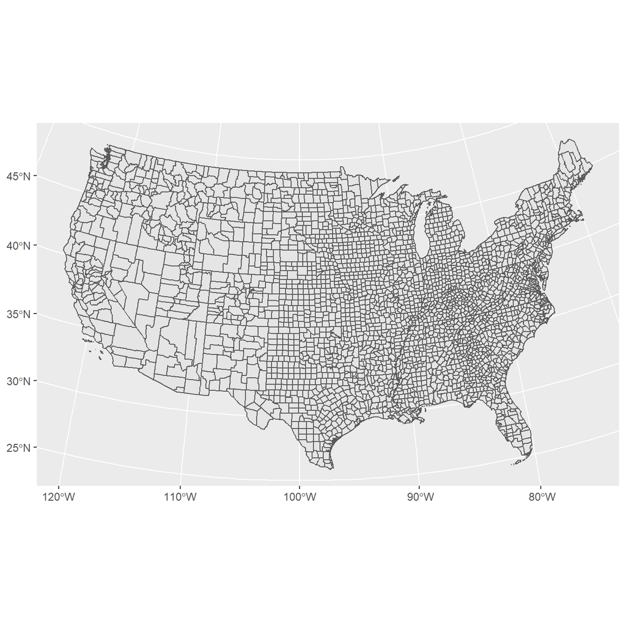

```r
library(sf)
us_co<-st_as_sf(us_co)
us_co$cofips<-paste(us_co$STATEFP, us_co$COUNTYFP, sep="")
us_co%>%
  ggplot()+
  geom_sf()+
  coord_sf(crs = 2163)
```

```r
final.dat<-merge( us_co,final.dat, by="cofips")
final.dat<-final.dat[order(final.dat$cofips),]
```

# Model setup

- We have a count outcome (deaths and births), in counties over time, and a set of time-constant covariates.
- We have several options in the GLM framework with which to model these data, for example:
- Binomial -
  $$y_{ij} \sim Bin(\pi_{ij}) \text{: } logit(\pi_{ij} ) = \beta_{0}+ x'\beta_k$$
- Poisson -
  $$y_{ij} \sim Pois(\lambda_{ij} E_{ij}) \text{: } log(\lambda_{ij} ) = log(E_{ij}) + \beta_{0}+ x'\beta_k$$
- Negative Binomial -
  $$y_{ij} \sim \text{Neg Bin} (\mu_{ij}, \alpha, E_{ij}) \text{: } log(\mu_{ij} ) = log(E_{ij}) + \beta_{0}+ x'\beta_k$$
- In addition to various zero-inflated versions of these data.

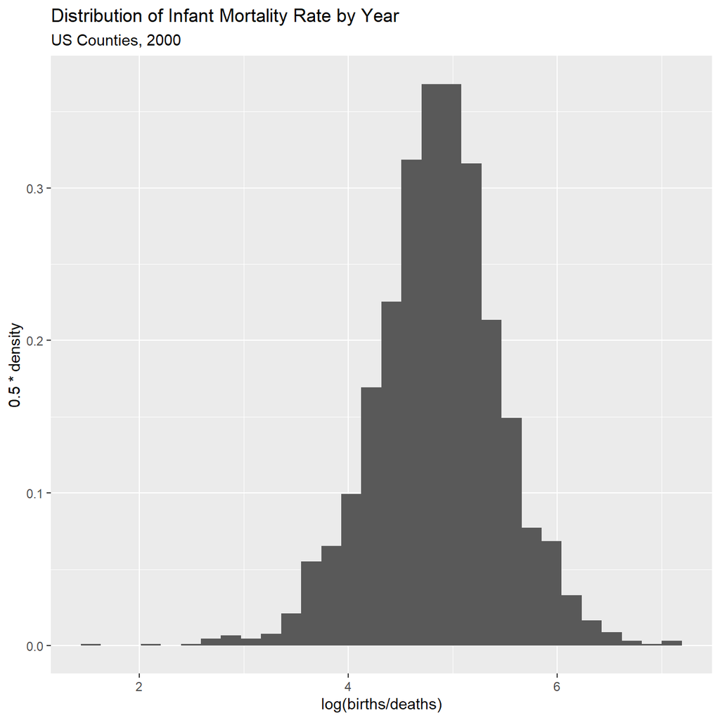

```r
ggplot(data = final.dat)+geom_histogram(aes(x =log(births/deaths) ,
                                            y=0.5*..density..))+
  #facet_wrap(~year)+
  ggtitle(label = "Distribution of Infant Mortality Rate by Year",
          subtitle = "US Counties, 2000")
```

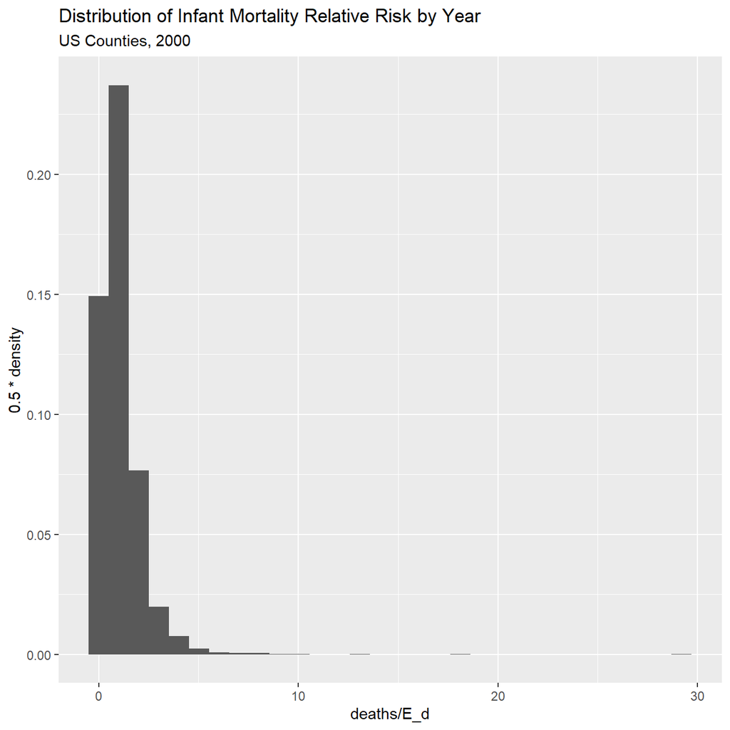

```r
ggplot(data = final.dat)+geom_histogram(aes(x =deaths/E_d ,
                                            y=0.5*..density..))+
  #facet_wrap(~year)+
  ggtitle(label = "Distribution of Infant Mortality Relative Risk by Year",
          subtitle = "US Counties, 2000")
```

```r
sts<- states(cb=T)%>%
  st_transform(crs= 2163)%>%
  st_boundary()%>%
  subset(!STATEFP%in%c("02", "15", "60", "66", "69", "72", "78"))
```

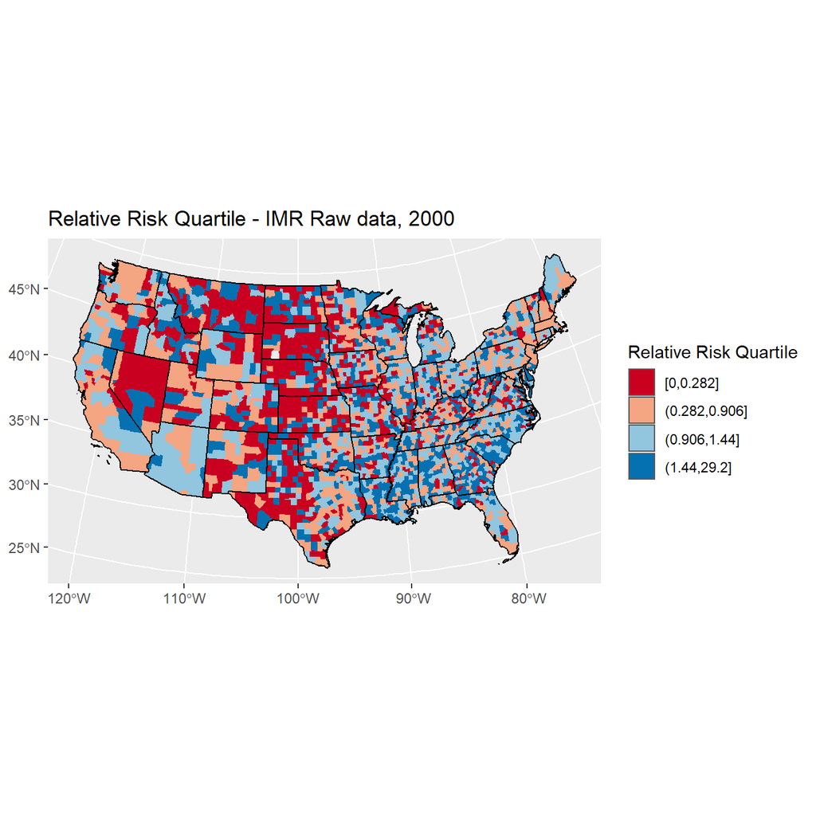

```r
final.dat%>%
  #filter(year%in%c(2000))%>%
  mutate(qrr=cut(I(deaths/E_d),
                 breaks = quantile(I(deaths/E_d),
                                   p=seq(0,1,length.out = 5)),
                 include.lowest = T))%>%
  ggplot()+
  geom_sf(aes(fill=qrr, color=NA))+
  geom_sf(data=sts, color="black")+
  scale_colour_brewer(palette = "RdBu" )+
  scale_fill_brewer(palette = "RdBu", na.value="grey")+
  guides(fill=guide_legend(title="Relative Risk Quartile"))+
  ggtitle(label="Relative Risk Quartile - IMR Raw data, 2000")+
  coord_sf(crs = 2163)
```

```r
#ggsave(filename = "C:/Users/ozd504/Documents/GitHub/talks/imr_raw2000.png", dpi = "print", width = 10, height = 8)
```

We can fit these model using the Bayesian framework with INLA.

$$\text{Deaths_ij} = \text{log(E_d)} + X' \beta$$

INLA will use vague Normal priors for the $\beta$’s, and we have not other parameters in the model to specify priors for. INLA does not require you to specify all priors, as all parameters have a default prior specification.

```r
#Model specification:
f1<-deaths~scale(pblack)+scale(phisp)+scale(ppov)

#Model fit
mod1<-inla(formula = f1,data = final.dat, #linear predictor - fixed effects
           family = "poisson", E = E_d,  #marginal distribution for the outcome, expected count
           control.compute = list(waic=T), # compute DIC or not?
           control.predictor = list(link=1), #estimate predicted values & their marginals or not?
           num.threads = 3,
               verbose = F)
#model summary
summary(mod1)
```

```
##
## Call:
##    c("inla(formula = f1, family = \"poisson\", data = final.dat, E = E_d,
##    ", " verbose = F, control.compute = list(waic = T), control.predictor =
##    list(link = 1), ", " num.threads = 3)")
## Time used:
##     Pre = 0.459, Running = 0.954, Post = 0.951, Total = 2.36
## Fixed effects:
##                 mean    sd 0.025quant 0.5quant 0.975quant   mode kld
## (Intercept)    0.024 0.008      0.008    0.024      0.041  0.024   0
## scale(pblack)  0.132 0.007      0.119    0.132      0.146  0.133   0
## scale(phisp)  -0.089 0.006     -0.100   -0.089     -0.078 -0.089   0
## scale(ppov)    0.091 0.008      0.075    0.091      0.108  0.091   0
##
## Watanabe-Akaike information criterion (WAIC) ...: 12250.23
## Effective number of parameters .................: 14.45
##
## Marginal log-Likelihood:  -6145.49
## Posterior marginals for the linear predictor and
##  the fitted values are computed
```

### Basic county level random intercept model

Now we add basic nesting of rates within counties, with a random intercept term for each county. This would allow there to be heterogeneity in the mortality rate for each county, over and above each county’s observed characteristics.

This model would be:

$$\text{Deaths}_{ij} = \text{log(E_d)} + X' \beta + u_j$$
$$u_j \sim \text{Normal} (0 , \tau_u)$$

where $\tau_u$ here is the precision, not the variance and **precision = 1/variance.**

INLA puts a log-gamma prior on the the precision by default.

```r
f2<-deaths~scale(pblack)+scale(phisp)+scale(ppov)+ #fixed effects
  f(struct, model = "iid")  #random effects

mod2<-inla(formula = f2,
           data = final.dat,
           family = "poisson",
           E = E_d,
           control.compute = list(waic=T),
           control.predictor = list(link=1),
           num.threads = 3,
               verbose = F)

#total model summary
summary(mod2)
```

```
##
## Call:
##    c("inla(formula = f2, family = \"poisson\", data = final.dat, E = E_d,
##    ", " verbose = F, control.compute = list(waic = T), control.predictor =
##    list(link = 1), ", " num.threads = 3)")
## Time used:
##     Pre = 0.355, Running = 3.59, Post = 2.44, Total = 6.38
## Fixed effects:
##                 mean    sd 0.025quant 0.5quant 0.975quant   mode kld
## (Intercept)    0.015 0.010     -0.005    0.015      0.035  0.015   0
## scale(pblack)  0.130 0.010      0.110    0.130      0.150  0.130   0
## scale(phisp)  -0.074 0.009     -0.093   -0.074     -0.056 -0.074   0
## scale(ppov)    0.098 0.011      0.075    0.098      0.120  0.098   0
##
## Random effects:
##   Name     Model
##     struct IID model
##
## Model hyperparameters:
##                       mean   sd 0.025quant 0.5quant 0.975quant  mode
## Precision for struct 26.46 2.96      21.22    26.26      32.88 25.85
##
## Watanabe-Akaike information criterion (WAIC) ...: 11731.75
## Effective number of parameters .................: 386.77
##
## Marginal log-Likelihood:  -5976.12
## Posterior marginals for the linear predictor and
##  the fitted values are computed
```

#### Marginal Distributions of hyperparameters

We can plot the posterior marginal of the hyperparameter in this model, in this case $\sigma_u = 1/\tau_u$

```r
m2<- inla.tmarginal(
        function(x) (1/x), #invert the precision to be on variance scale
        mod2$marginals.hyperpar$`Precision for struct`)
#95% credible interval for the variance
inla.hpdmarginal(.95, marginal=m2)
```

```
##                   low       high
## level:0.95 0.03001431 0.04677932
```

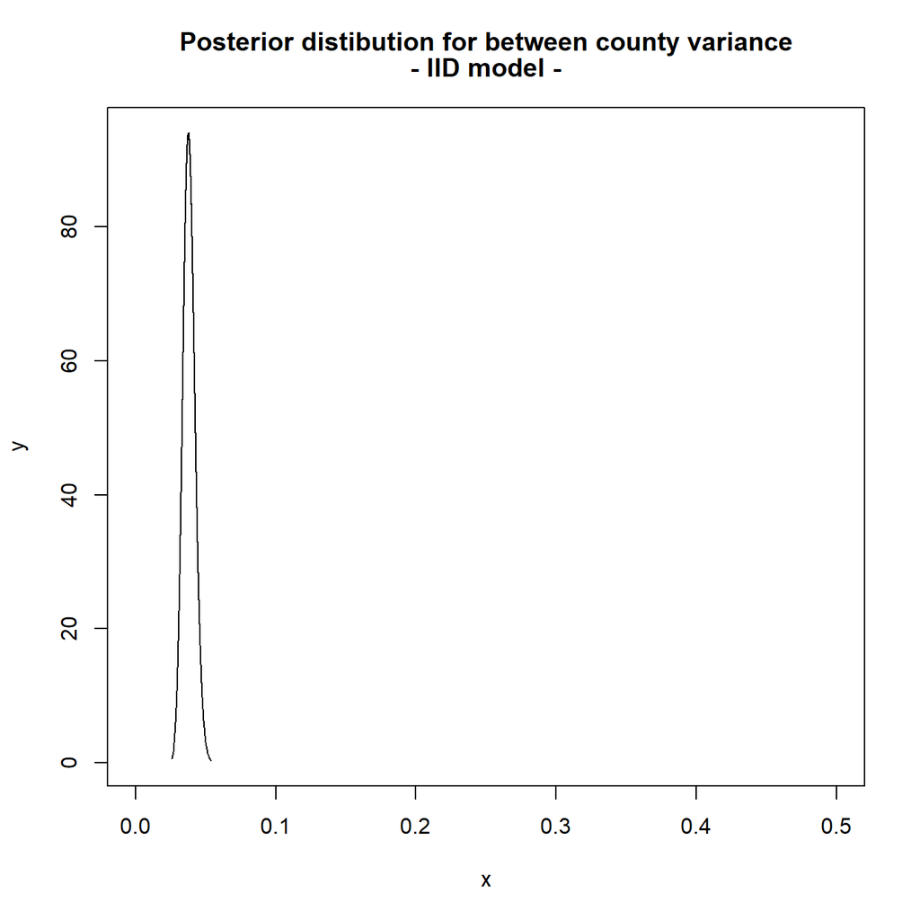

```r
plot(m2,
     type="l",
     main=c("Posterior distibution for between county variance", "- IID model -"),
     xlim=c(0, .5))
```

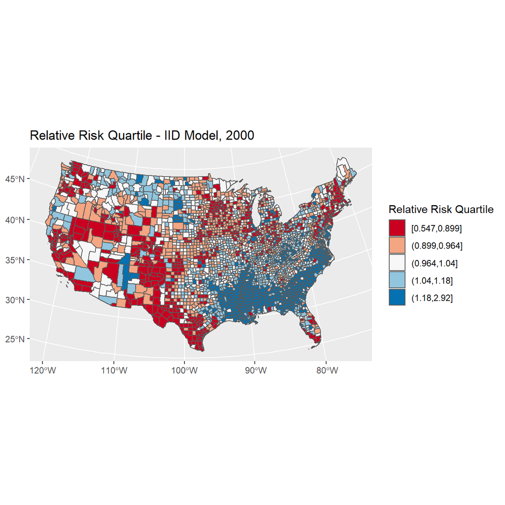

```r
final.dat$fitted_m2<-mod2$summary.fitted.values$mean

final.dat%>%
#  filter(year%in%c(2000))%>%
  mutate(qrr=cut(fitted_m2,
                 breaks = quantile(fitted_m2, p=seq(0,1,length.out = 6)),
                 include.lowest = T))%>%
  ggplot()+geom_sf(aes(fill=qrr))+
  scale_colour_brewer(palette = "RdBu" )+
  scale_fill_brewer(palette = "RdBu", na.value="grey")+
  guides(fill=guide_legend(title="Relative Risk Quartile"))+
  ggtitle(label="Relative Risk Quartile - IID Model, 2000")+
  coord_sf(crs = 2163)
```

```r
# library(mapview)
#
# map1<-final.dat%>%
#   filter(year%in%c(2007))%>%
#   mutate(qrr=cut(fitted_m2, breaks = quantile(fitted_m2, p=seq(0,1,length.out = 8))))
# clrs <- colorRampPalette(brewer.pal(8, "RdBu"))
# mapView(as(map1, "Spatial"), zcol="qrr", legend=T, col.regions=clrs)
```

### BYM Model

Model with spatial correlation - Besag, York, and Mollie (1991) model
$$\text{Deaths}_{ij} = \text{log(E_d)} + X' \beta + u_j + v_j$$
Which has two random effects, one an IID random effect and the second a spatially correlated random effect, specified as a conditionally auto-regressive prior for the $v_j$’s. This is the Besag model:

For the BYM model we must specify the spatial connectivity matrix in the random effect.

```r
f3<-deaths~scale(pblack)+scale(phisp)+scale(ppov)+
  f(struct, model = "bym",scale.model = T, constr = T, graph = H)

mod3<-inla(formula = f3,data = final.dat,
           family = "poisson",
           E = E_d,
           control.compute = list(waic=T,return.marginals.predictor=TRUE),
           control.predictor = list(link=1),
           num.threads = 3,
               verbose = F)

#total model summary
summary(mod3)
```

```
##
## Call:
##    c("inla(formula = f3, family = \"poisson\", data = final.dat, E = E_d,
##    ", " verbose = F, control.compute = list(waic = T,
##    return.marginals.predictor = TRUE), ", " control.predictor = list(link
##    = 1), num.threads = 3)")
## Time used:
##     Pre = 0.61, Running = 7.8, Post = 2.63, Total = 11
## Fixed effects:
##                 mean    sd 0.025quant 0.5quant 0.975quant   mode kld
## (Intercept)    0.026 0.011      0.004    0.026      0.048  0.026   0
## scale(pblack)  0.116 0.013      0.090    0.116      0.141  0.116   0
## scale(phisp)  -0.037 0.014     -0.065   -0.037     -0.008 -0.037   0
## scale(ppov)    0.095 0.013      0.070    0.095      0.120  0.095   0
##
## Random effects:
##   Name     Model
##     struct BYM model
##
## Model hyperparameters:
##                                           mean    sd 0.025quant 0.5quant
## Precision for struct (iid component)     63.04 18.38      35.19    60.23
## Precision for struct (spatial component) 39.01 12.32      19.76    37.39
##                                          0.975quant  mode
## Precision for struct (iid component)         106.61 55.01
## Precision for struct (spatial component)      67.84 34.30
##
## Watanabe-Akaike information criterion (WAIC) ...: 11684.21
## Effective number of parameters .................: 332.75
##
## Marginal log-Likelihood:  -4876.79
## Posterior marginals for the linear predictor and
##  the fitted values are computed
```

Compare model fits

```r
mod1$waic$waic
```

```
## [1] 12250.23
```

```r
mod2$waic$waic
```

```
## [1] 11731.75
```

```r
mod3$waic$waic
```

```
## [1] 11684.21
```

Looks like the spatial is better in this case.

#### Regression effect posterior distributions

If we want to get the 95% credible interval for a risk ratio $exp(\beta)$, we can do so using the `inla.emarginal()` and `inla.tmarginal()` functions

```r
b1 <- inla.emarginal(exp, mod2$marginals.fixed[[2]])
b1 #Posterior mean
```

```
## [1] 1.138849
```

```r
b1ci <-inla.qmarginal(c(.025, .975),
                      inla.tmarginal(exp, mod2$marginals.fixed[[2]]))
b1ci
```

```
## [1] 1.116277 1.161711
```

#### Hyper parameter distributions

Green line is spatial variation, black line is nonspatial variation

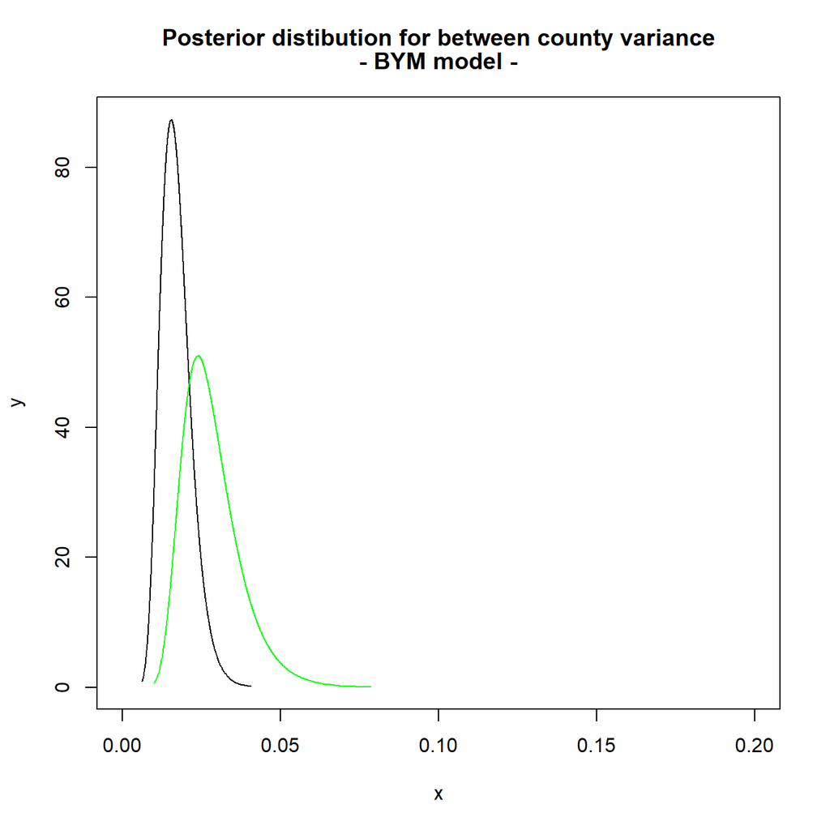

```r
m3a<- inla.tmarginal(
        function(x) (1/x),
        mod3$marginals.hyperpar$`Precision for struct (iid component)`)
m3b<- inla.tmarginal(
        function(x) (1/x),
        mod3$marginals.hyperpar$`Precision for struct (spatial component)`)

plot(m3a, type="l",
     main=c("Posterior distibution for between county variance", "- BYM model -"),
     xlim=c(0, .2)) # you may need to change this
#lines(m3b, col="red")
lines(m3b, col="green")
```

HPD interval for variances

```r
inla.hpdmarginal(.95,m3a)
```

```
##                    low       high
## level:0.95 0.008540118 0.02681006
```

```r
inla.hpdmarginal(.95,m3b)
```

```
##                   low       high
## level:0.95 0.01299861 0.04660598
```

## Spatial mapping of the fitted values

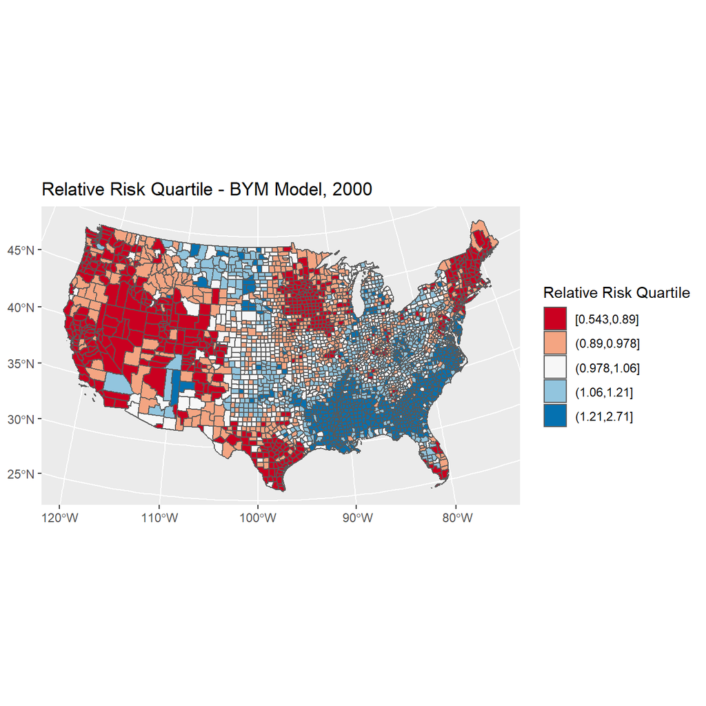

```r
final.dat$fitted_m3<-mod3$summary.fitted.values$mean

final.dat%>%
 # filter(year%in%c(2000))%>%
  mutate(qrr=cut(fitted_m3,
                 breaks = quantile(fitted_m3, p=seq(0,1,length.out = 6)),
                 include.lowest = T))%>%
  ggplot()+
  geom_sf(aes(fill=qrr))+
  scale_colour_brewer(palette = "RdBu" )+
  scale_fill_brewer(palette = "RdBu", na.value="grey")+
  guides(fill=guide_legend(title="Relative Risk Quartile"))+
  ggtitle(label="Relative Risk Quartile - BYM Model, 2000")+
  coord_sf(crs = 2163)
```

```r
#library(mapview)

#map1<-final.dat%>%
#  filter(year%in%c(2007))%>%
#  mutate(qrr=cut(fitted_m3, breaks = quantile(fitted_m3, p=seq(0,1,length.out = 8))))
#clrs <- colorRampPalette(brewer.pal(8, "RdBu"))
#mapView(as(map1, "Spatial"), zcol="qrr", legend=T, col.regions=clrs)
```

## Map of spatial random effects

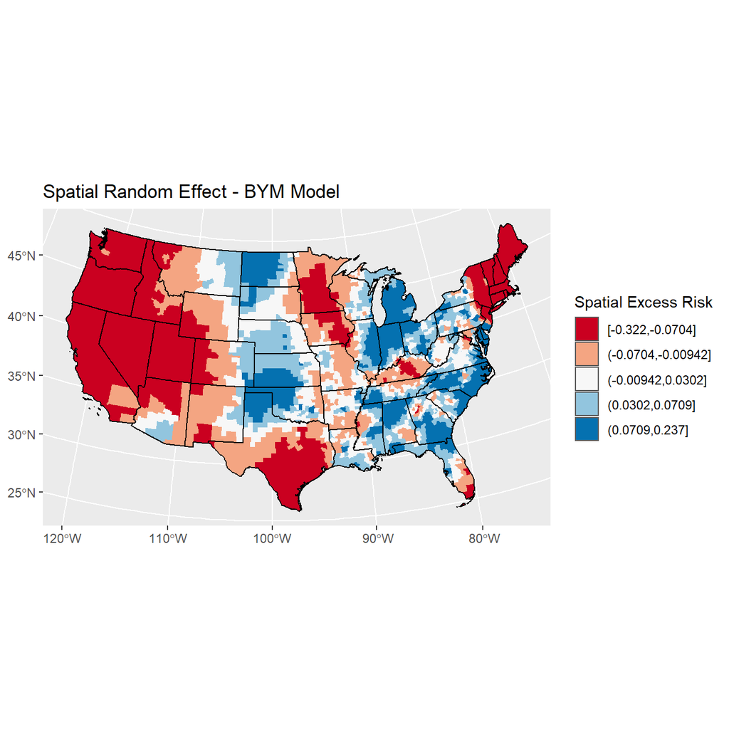

```r
us_co$sp_re<-mod3$summary.random$struct$mean[3109:6216]
us_co%>%
  mutate(qse=cut(sp_re,
                 breaks = quantile(sp_re, p=seq(0,1,length.out = 6)),
                 include.lowest = T))%>%
  ggplot()+
  geom_sf(aes(fill=qse, color=NA))+
  geom_sf(data=sts)+
  scale_colour_brewer(palette = "RdBu" )+
  scale_fill_brewer(palette = "RdBu", na.value="grey")+
  guides(fill=guide_legend(title="Spatial Excess Risk"))+
  ggtitle(label="Spatial Random Effect - BYM Model")+
  coord_sf(crs = 2163)
```

IID random effect

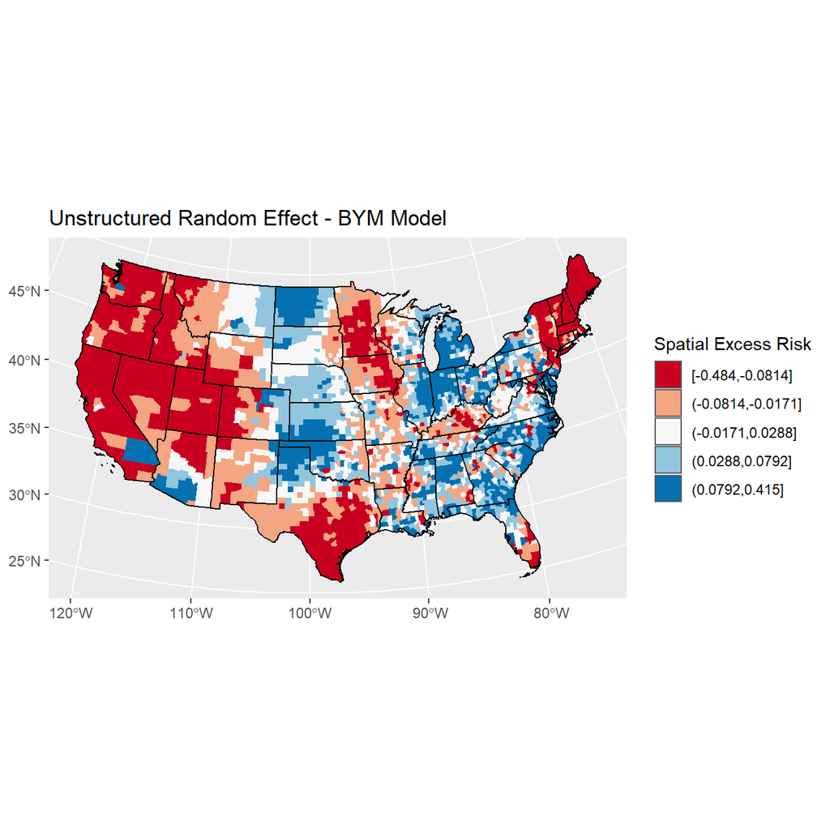

```r
us_co$i_re<-mod3$summary.random$struct$mean[1:3108]
us_co%>%
  mutate(qse=cut(i_re,
                 breaks = quantile(i_re, p=seq(0,1,length.out = 6)),
                 include.lowest = T))%>%
  ggplot()+
  geom_sf(aes(fill=qse, color=NA))+
  geom_sf(data=sts)+
  scale_colour_brewer(palette = "RdBu" )+
  scale_fill_brewer(palette = "RdBu", na.value="grey")+
  guides(fill=guide_legend(title="Spatial Excess Risk"))+
  ggtitle(label="Unstructured Random Effect - BYM Model")+
  coord_sf(crs = 2163)
```

## Exceedence probabilities

To get the exceedence probabilities from one of our models, we can use the `inla.pmarginal()` function to ask if $\text{Pr}(\theta \gt \theta^*)$

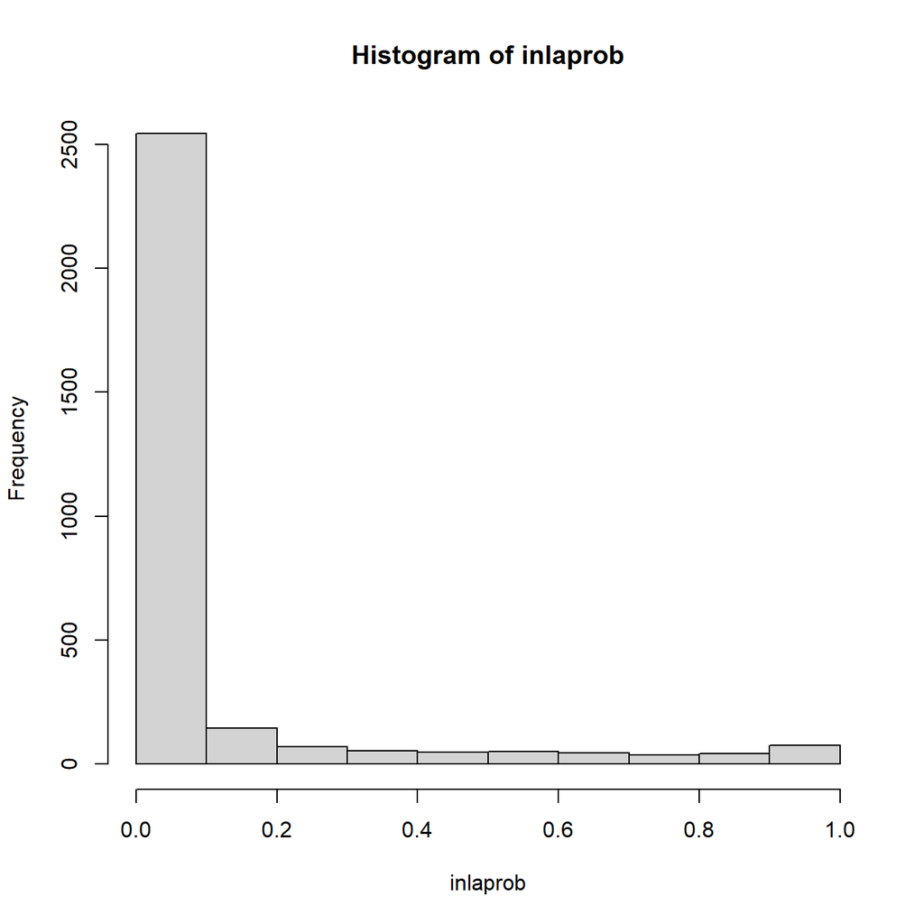

```r
thetastar<-1.5#theta*
inlaprob<- unlist(lapply(mod3$marginals.fitted.values, function(X){
   1-inla.pmarginal(thetastar, X)
}))
hist(inlaprob)
```

So, we see lots of occasions where the exceedence probability is greater than .9. We can visualize these in a map.

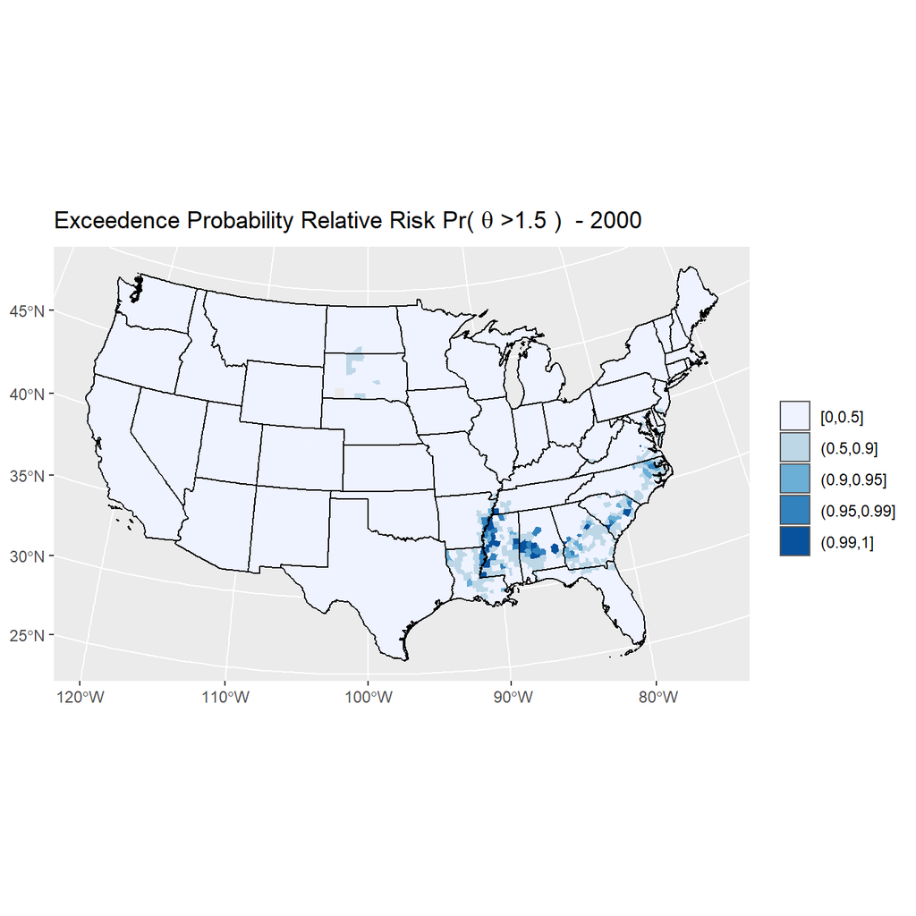

```r
final.dat$exceedprob<-inlaprob

final.dat%>%
 # filter(year%in%c(2000))%>%
  mutate(qrr=cut(exceedprob,
                 breaks = c(0, .5, .9, .95, .99, 1),
                 include.lowest = T))%>%
  ggplot()+
  geom_sf(aes(fill=qrr, color=NA))+
  geom_sf(data=sts)+
  scale_colour_brewer(palette = "Blues" )+
  scale_fill_brewer(palette = "Blues", na.value="grey")+
  guides(fill=guide_legend(title=""))+
  ggtitle(label=expression(paste("Exceedence Probability Relative Risk ","Pr( ",theta," >1.5"," )  - 2000") ))+
  coord_sf(crs = 2163)
```

```r
#map1<-final.dat%>%
 # filter(year%in%c(2007))%>%
#  mutate(qrr=cut(exceedprob, breaks = c(0, .5, .9, .95, .99, 1), include.lowest = T))

#clrs <- colorRampPalette(brewer.pal(6, "Blues"))
#mapView(as(map1, "Spatial"), zcol="qrr", legend=T, col.regions=clrs, map.types="OpenStreetMap")
```

Which shows several areas where risk the mortality rate is higher than the national rate.

## Alternative priors

To see available priors you can do:

```r
names(inla.models()$prior)
```

```
##  [1] "normal"                 "gaussian"               "linksnintercept"
##  [4] "wishart1d"              "wishart2d"              "wishart3d"
##  [7] "wishart4d"              "wishart5d"              "loggamma"
## [10] "gamma"                  "minuslogsqrtruncnormal" "logtnormal"
## [13] "logtgaussian"           "flat"                   "logflat"
## [16] "logiflat"               "mvnorm"                 "pc.alphaw"
## [19] "pc.ar"                  "dirichlet"              "none"
## [22] "invalid"                "betacorrelation"        "logitbeta"
## [25] "pc.prec"                "pc.dof"                 "pc.cor0"
## [28] "pc.cor1"                "pc.fgnh"                "pc.spde.GA"
## [31] "pc.matern"              "pc.range"               "pc.sn"
## [34] "pc.gamma"               "pc.mgamma"              "pc.gammacount"
## [37] "pc.gevtail"             "pc"                     "ref.ar"
## [40] "pom"                    "jeffreystdf"            "expression:"
## [43] "table:"
```

To see the default priors for a particular model do:

```r
inla.models()$latent$bym$hyper$theta1$name
```

```
## [1] "log unstructured precision"
## attr(,"inla.read.only")
## [1] FALSE
```

```r
inla.models()$latent$bym$hyper$theta1$prior
```

```
## [1] "loggamma"
## attr(,"inla.read.only")
## [1] FALSE
```

```r
inla.models()$latent$bym$hyper$theta1$param
```

```
## [1] 1.0000 0.0005
## attr(,"inla.read.only")
## [1] FALSE
```

```r
inla.models()$latent$bym$hyper$theta2$name
```

```
## [1] "log spatial precision"
## attr(,"inla.read.only")
## [1] FALSE
```

```r
inla.models()$latent$bym$hyper$theta2$prior
```

```
## [1] "loggamma"
## attr(,"inla.read.only")
## [1] FALSE
```

```r
inla.models()$latent$bym$hyper$theta2$param
```

```
## [1] 1.0000 0.0005
## attr(,"inla.read.only")
## [1] FALSE
```

```r
inla.models()$prior$logtgaussian
```

```
## $doc
## [1] "Truncated Gaussian prior"
##
## $nparameters
## [1] 2
##
## $pdf
## [1] "prior-logtnorm"
```

```r
prec.prior <- list(prec.unstruct = list(prior = "logtgaussian", param = c(0.2, 1)),
                   prec.spatial = list(prior = "logtgaussian", param = c(0.2, 1)))


f4<-deaths~scale(pblack)+scale(phisp)+scale(ppov)+
  f(struct, model = "bym",scale.model = T, constr = T, graph = H,
    hyper = prec.prior)

mod4<-inla(formula = f4,data = final.dat,
           family = "poisson",
           E = E_d,
           control.compute = list(waic=T,return.marginals.predictor=TRUE),
           control.predictor = list(link=1),
           num.threads = 3,
               verbose = F)

summary(mod4)
```

```
##
## Call:
##    c("inla(formula = f4, family = \"poisson\", data = final.dat, E = E_d,
##    ", " verbose = F, control.compute = list(waic = T,
##    return.marginals.predictor = TRUE), ", " control.predictor = list(link
##    = 1), num.threads = 3)")
## Time used:
##     Pre = 0.743, Running = 7.81, Post = 1.94, Total = 10.5
## Fixed effects:
##                 mean    sd 0.025quant 0.5quant 0.975quant   mode kld
## (Intercept)    0.026 0.011      0.004    0.026      0.047  0.026   0
## scale(pblack)  0.116 0.013      0.090    0.116      0.142  0.115   0
## scale(phisp)  -0.036 0.015     -0.064   -0.036     -0.007 -0.036   0
## scale(ppov)    0.095 0.013      0.069    0.095      0.120  0.095   0
##
## Random effects:
##   Name     Model
##     struct BYM model
##
## Model hyperparameters:
##                                           mean    sd 0.025quant 0.5quant
## Precision for struct (iid component)     60.91 16.77      34.83    58.59
## Precision for struct (spatial component) 36.47 10.83      19.50    35.05
##                                          0.975quant  mode
## Precision for struct (iid component)         100.25 54.22
## Precision for struct (spatial component)      61.71 32.37
##
## Watanabe-Akaike information criterion (WAIC) ...: 11679.49
## Effective number of parameters .................: 338.19
##
## Marginal log-Likelihood:  -4875.27
## Posterior marginals for the linear predictor and
##  the fitted values are computed
```

```r
mod4$waic$waic
```

```
## [1] 11679.49
```

```r
mod3$waic$waic
```

```
## [1] 11684.21
```

```r
mod2$waic$waic
```

```
## [1] 11731.75
```

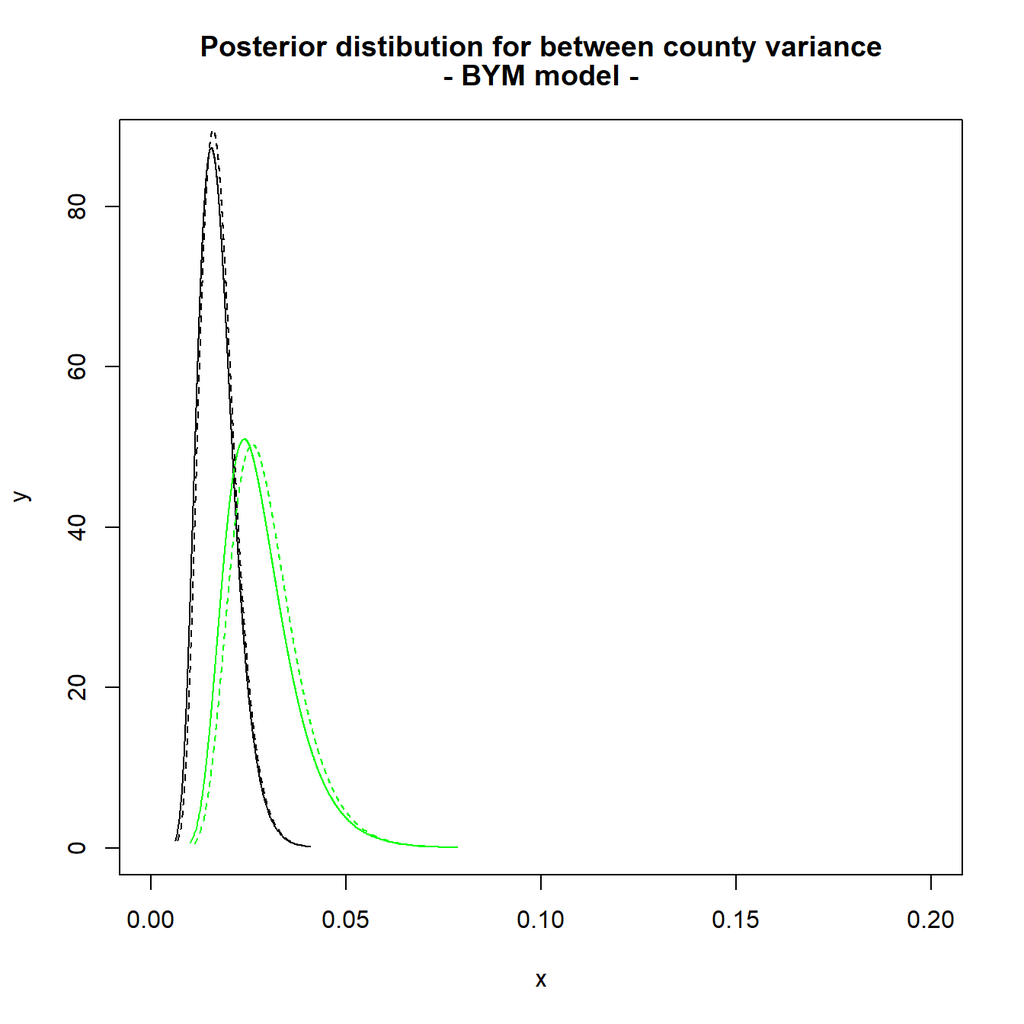

```r
m4a<- inla.tmarginal(
        function(x) (1/x),
        mod4$marginals.hyperpar$`Precision for struct (iid component)`)
m4b<- inla.tmarginal(
        function(x) (1/x),
        mod4$marginals.hyperpar$`Precision for struct (spatial component)`)

plot(m3a, type="l",
     main=c("Posterior distibution for between county variance", "- BYM model -"),
     xlim=c(0, .2))
#lines(m3b, col="red")
lines(m3b, col="green")
lines(m4a, col="black", lty=2)# modified prior for IID
lines(m4b, col="green", lty=2)# modified prior for spatial
```

## Zero inflation

Often in count data when the outcome is rare, we can have more zeros present in the data than (expecially) the Poisson distribution will allow. In this case, a zero-inflated model can be used. A zero-inflated model splits the model into two components. The first component models the extra 0’s in the data while the second component models the count outcome.

```r
 f5<-deaths~scale(pblack)+scale(phisp)+scale(ppov)+
  f(struct, model = "bym",scale.model = T, constr = T, graph = H)

mod5<-inla(formula = f5,data = final.dat,
           family = "zeroinflatedpoisson0",
           E = E_d,
           control.compute = list(waic=T,return.marginals.predictor=TRUE),
           control.predictor = list(link=1),
           num.threads = 3,
               verbose = F)

#total model summary
summary(mod5)
```

```
##
## Call:
##    c("inla(formula = f5, family = \"zeroinflatedpoisson0\", data =
##    final.dat, ", " E = E_d, verbose = F, control.compute = list(waic = T,
##    return.marginals.predictor = TRUE), ", " control.predictor = list(link
##    = 1), num.threads = 3)")
## Time used:
##     Pre = 0.666, Running = 8.95, Post = 2.01, Total = 11.6
## Fixed effects:
##                 mean    sd 0.025quant 0.5quant 0.975quant   mode kld
## (Intercept)    0.039 0.012      0.016    0.039      0.063  0.040   0
## scale(pblack)  0.115 0.013      0.089    0.115      0.141  0.115   0
## scale(phisp)  -0.044 0.014     -0.071   -0.044     -0.015 -0.044   0
## scale(ppov)    0.100 0.013      0.074    0.100      0.126  0.100   0
##
## Random effects:
##   Name     Model
##     struct BYM model
##
## Model hyperparameters:
##                                                          mean     sd 0.025quant
## zero-probability parameter for zero-inflated poisson_0  0.241  0.008      0.226
## Precision for struct (iid component)                   52.869 11.760     33.091
## Precision for struct (spatial component)               58.682 22.493     27.286
##                                                        0.5quant 0.975quant
## zero-probability parameter for zero-inflated poisson_0     0.24      0.256
## Precision for struct (iid component)                      51.77     79.256
## Precision for struct (spatial component)                  54.45    114.206
##                                                         mode
## zero-probability parameter for zero-inflated poisson_0  0.24
## Precision for struct (iid component)                   49.70
## Precision for struct (spatial component)               47.16
##
## Watanabe-Akaike information criterion (WAIC) ...: 13043.08
## Effective number of parameters .................: 301.75
##
## Marginal log-Likelihood:  -5555.37
## Posterior marginals for the linear predictor and
##  the fitted values are computed
```

```r
mod5$waic$waic
```

```
## [1] 13043.08
```

```r
mod4$waic$waic
```

```
## [1] 11679.49
```

In this case, the zero inflation model does not improve up on the Poisson.

## References

Besag, J., York, J., & Mollie, a. (1991). Bayesian image-restoration, with 2 applications in spatial statistics. Annals of the Institute of Statistical Mathematics, 43(1), 1-20. https://doi.org/10.1007/BF00116466